# Data Preprocessing

# Introduction

Here I document the data preprocessing for this activity. Essentially what I want is a set of files that can be used to produce maps in a relatively simple way (at this point I don’t want to discuss the conversion of `Spatial*` and `Spatial*DataFrame` dataframes into the type of dataframes used by `ggmap`).

Therefore, I will convert the shape file into dataframes that students can readily use.

# Data preprocessing

Begin by loading the libraries needed to do this:

```r
library(rgdal)
library(readxl)
library(dplyr)
library(ggplot2)
library(tmap)
library(ggmap)
library(broom)
library(readr)
```

```r
library(cartogram)
library(gridExtra)
```

I can now proceed to see read the geospatial file.

```r
DA <- readOGR(".", layer = "Hamilton CMA DA", integer64 = "allow.loss")
```

This creates a `SpatialPolygonsDataFrame`, an R object used to store geographical information (in this example spatial polygons; other types of spatial data are points, lines, or pixels; more generally `Spatial*DataFrames`).

Now that I have a `SpatialPolygonDataFrame` object, I need to create a “tidy” version of it; in the present case this means the SpatialPolygonDataFrame `taz`. This is done by means of the `tidy` function of the `broom` package. We will call it `taz.t` for “tidy” (note that `tidy` needs to know the id that will be used to create the regions, that is, the spatial polygons; since this will be renamed `id` by `tidy`, we need to rename it to “GTA06” to keep it consistent with table data):

```r
taz.t <- tidy(taz, region = "GTA06")
#Rename id column
taz.t <- rename(taz.t, GTA06 = "id")
```

I have now a data frame that can be plotted in `ggmap`.

Import data:

```r
data <- read_csv("TTS Equivalent CTs.csv")
data$GTA06 <- as.factor(data$GTA06)
```

Add variables to the tidied dataframe:

```r
taz.t <- left_join(taz.t, data, by = "GTA06")
```

Add variables to the spatial dataframe:

```r
taz@data <- left_join(taz@data, data, by = "GTA06")
```

Create maps!

```r
leaflet(data = taz) %>% addPolygons() %>% addTiles()
```

```r
cart_pop <- cartogram(shp = taz, weight = "Population")
```

[output not shown]

```r
cart_pop.t <- tidy(cart_pop, region = "GTA06")
cart_pop.t <- rename(cart_pop.t, GTA06 = "id")
```

Add variables to the tidied dataframe:

```r
cart_pop.t <- left_join(cart_pop.t, data, by = "GTA06")
```

```
Column `GTA06` joining character vector and factor, coercing into character vector
```

```r
cart_pop.map <- ggplot(data = cart_pop.t, aes(x = long, y = lat, group = group, fill = cut_number(Population, 5))) + geom_polygon(color = "white") + coord_fixed() + theme(legend.position = "bottom")
```

```r
pop.map <- ggplot(data = taz.t, aes(x = long, y = lat, group = group, fill = cut_number(Population, 5))) + geom_polygon(color = "white") + coord_fixed()  + theme(legend.position = "bottom")
```

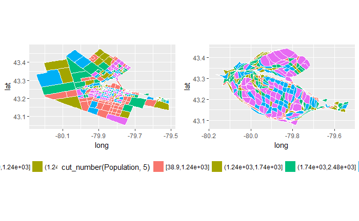

```r
grid.arrange(pop.map, cart_pop.map, nrow = 1)
```

Obtain a base map. For this, the argument must specify the location for the capture. The outcome can be saved as an object that can later be used for mapping:

```r
hamilton <- get_map("Hamilton, Ontario")
```

The function `ggmap` allows you to create a base map to which other geometric objects (or geoms, in the terminology of `ggplot2`) can be added as layers. For instance, plot the traffic analysis zones on your base map:

```r
ggmap(hamilton) +
  geom_polygon(data = taz.t, aes(x = long, y = lat, group = group), colour = 'black', alpha = .3, size = .3)
```

[output not shown]

```r
ggmap(hamilton, extent = "panel") +
  geom_polygon(data = taz.t, aes(x = long, y = lat, group = group, fill = cut_number(`Avg Median Age`, 5)), colour = 'black', alpha = 1, size = .3) +
  scale_fill_brewer(palette = "Reds")
```

[output not shown]

Save the dataset for use in the activity:

```r
HamiltonDAs <- taz.t
save(HamiltonDAs, file = "HamiltonDAs.RData")
```